# Data Science with `R` Project Proposal

Team: COVID-19 Predictor

20.05.2020

# Project Title: COVID-19 Prediction using Explainable Machine Learning

## Project Objective:

From the motivation to help flattening the curve of COVID-19,

> Can we use a Data Science for COVID-19 diagnosis?

To answer the this question, we aim to answer few sub-questions:

- How well could classifiers perform on Chest X-Rays?
- Although [2] and [3] extensively works with Neural Networks (Black-Box Model) to classify, Can simple and intrinsically explainable classifiers achieve a base Accuracy, F<sub>1</sub>-Score and AUC of 85% using CXR?
- How does different features of CXR contribute to the model prediction and Can we come up with few number of feature w.r.t their importance?
- Which flavour of algorithm perform best among all and is there a possibility of Classification in Ensemble setting?
- Can we come up with explaination of our model’s decsision and prediction?

## Ground Truth and Technology Stack:

### Technology Stack

The project will be built in `R` with usage of API’s like `magick`, `opencv` for image processing and `tidyverse` packages like `dplyr` and `tidyr` for data manipulation, `ggplot2` for data visualization, `rmarkdown` and `knitr` for reproducible and automated reporting, `shiny` for interactive web applications and `tidymodels` for inferential and predictive modeling.

### Dataset

Our Dataset consists of 313 Positive COVID CXR and 1000 Negative CXR collected from four different sources to make our version of the dataset to work upon. This includes COVIDx dataset of [3][^1], Kaggle CXR Pneumonia dataset by Paul Mooney,[^2] CXR images of adult subjects from the RSNA Pneumonia Detection Challenge,[^3] original and augmented versions of COVID-19 examples[^4] from [4].

According to [2,3,5,6] CT-Scan data would be gold-standard for us and also potray pretty good results evaluated in terms of Accuracy and F<sub>1</sub>-Score. However, due to CT Scan being available in very less quantity publicly, we would like to use Chest X-rays as our dataset. Though, it won’t be that competible in terms of quality w.r.t CT-Scans but [7] suggests CXR to be sufficient and comparable to CT-Scans in order to diagnose COVID-19 patients.

In particular we will use the [COVID-19 Dataset Repository](https://shorturl.at/qwLR0) as our Ground Truth.

### Github

The `R` scripts, process notebook and other resources have been stored at the [repository](https://github.com/JalajVora/Data-Science-with-R-Project).

## Design overview (Algorithms and Methods):

We would be following a typical Data Science pipeline starting with Pre-Processing of the Dataset, Feature Extraction and Selection and then feeding Descriptors (Trainable Vectors) to different classifiers to train and test and then finally evaluation would be done based on predictor’s results. The details are delineated in the following sections:

- **Pre-Processing**
  - There exist several texture-based vision algorithms. We will try to combine features before training and train our model on a combined feature set; Or else we can train models on individual features, and then combine prediction results might be combined and thus one feature might only not be selected but multiple features can be selected [8].
  - Literature survey tells us Local Binary Patterns [9] shall be a good choice for texture-based descriptor.
  - We will also try to use pretrained networks to gain texture descriptors or vision API’s for the extraction part. Moreover, there are several Neural-Nets we faced in literature survey, that are carefully curated for the purpose of the COVID-19, which requires the image to directly fed to the net, and thereby auto-encodes the parameters [8].
- **Classification**
  - The problem in hand is a classification problem where we would be classifying an image being COVID-19 positive or negative along with a class imbalance problem [10].
  - Here, we would like to emphasize that the model won’t predict presence or absence or pneumonia, which is a result not only of COVID-19 but other kind of reasons also affect this.
  - We intend to work on following algorithms:
    - Clustering Algorithms
      - k-Means
      - kNN
    - Support Vector Machines
    - Binary Classifiers
      - Decision Trees
      - Naive Bayes
  - Mostly because the models are intrinsically explainable.

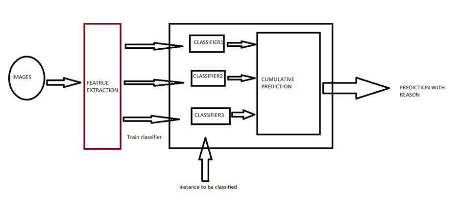

  - The above figure suggests the overall overview of an architecture of the system we would like to develop.
- **Evaluation**
  - The higher the metric value the better the performance.
  - *Accuracy:* Best and mostly used metric. Easily suited for binary as well as multiclass classification problem.
  - *Precision:* It is a best choice when we want to be very sure of our prediction.
  - *Recall:* Captures as many positives as possible
  - *F<sub>1</sub>-Score:* It is a harmonic mean between Precision and Recall.
  - *AUC & ROC:* Indicates how well the probabilities from the positive classes are separated from the negative classes. ROC is the probability curve and AUC represents degree or measure of separability.

## Time Plan:

> **2 Meetings per week. Tuesday and Friday at 17:30 Sharp via [Zoom](https://ovgu.zoom.us/j/8905371732?pwd=b2ExRjZFazRON3VGK2s0cjgvWXVYZz09)[^5]. Every Friday, Weekly Achievements would be discussed.**

Timeline

| Work_Slot | Date | Deadline | Member_Name | Task_Assigned |  |  |  |
| --- | --- | --- | --- | --- | --- | --- | --- |
| 1 | 22.05.2020 - 28.05.2020 | 28.05.2020 – 23:59 | Jalaj and Subhankar | Data Acquisitionand Data Pre-Processing Literature Reivew |  |  |  |
|  |  |  | Shivam and Subhajit | Feature Engineering and Model Selection Literature Review |  |  |  |
|  |  |  | Roshmitha | EDA Methodology, Visualisation and Evaluation Literature Review |  |  |  |
| 2 | 29.05.2020 - 04.06.2020 | 04.06.2020 – 23:59 | Jalaj | Experimenting with SVM on Data |  |  |  |
|  |  |  | Shivam | Experimenting with Logistic Regression and Perceptron on Data |  |  |  |
|  |  |  | Shubhankar | Experimenting with Decision Trees and Random Forest on Data |  |  |  |
|  |  |  | Subhajit | Experimenting with SVM with Gausian Kernel and EM-Algorithms on Data |  |  |  |
|  |  |  | Roshmitha | Experimenting with Bayesian Algorithms on Data |  |  |  |
| 3 | 05.06.2020 - 19.06.2020 | 18.06.2020 – 23:59 | Jalaj | Literature Review and Implemetation of Interpretebility of features for covid-dataset |  |  |  |
|  |  |  | Subhajit |  |  |  |  |
|  |  |  | Shivam |  |  |  |  |
|  |  |  | Subhankar |  |  |  |  |
|  |  |  | Roshmitha |  |  |  |  |
| 4 | 19.06.2020 - 02.07.2020 | 02.07.2020 – 23:59 | Jalaj |  | Literature Review and Implemetation of Ensemble Classifier Setting |  |  |
|  |  |  | Subhajit |  |  |  |  |
|  |  |  | Shivam |  |  |  |  |
|  |  |  | Subhankar |  |  | Evaluation Metrics on Intrinsically Interpretable Algorithms |  |
|  |  |  | Roshmitha |  |  |  |  |
| 5 | 03.07.2020 - 09.07.2020 | 08.07.2020 – 23:59 | Jalaj |  |  |  | R Markdown Process Notebook |
|  |  |  | Subhajit |  | Final Presentation |  |  |
|  |  |  | Shivam | Project Screencast |  |  |  |
|  |  |  | Subhankar and Roshmitha | Project Website |  |  |  |

## Team:

- **Jalaj, Vora** *M.Sc. Digital Engineering*
- **Shivam, Singh** *M.Sc. Digital Engineering*
- **Subhankar, Patra** *M.Sc. Data and Knowledge Engineering*
- **Subhajit, Mondal** *M.Sc. Data and Knowledge Engineering*
- **Roshmitha, Thummala** *M.Sc. Data and Knowledge Engineering*

**Supervised by:** [M.Sc. Uli Niemann](http://www.kmd.ovgu.de/Team/Academic+Staff/Uli+Niemann.html)

# References

[1] World Health Organisation, Novel Coronavirus – China 2020, (2020). https://www.who.int/csr/don/12-january-2020-novel-coronavirus-china/en/.

[2] J. Zhao, Y. Zhang, X. He, P. Xie, COVID-ct-dataset: A ct scan dataset about covid-19, ArXiv. abs/2003.13865 (2020).

[3] M. Karim, T. Döhmen, D. Rebholz-Schuhmann, S. Decker, M. Cochez, O. Beyan, others, Deepcovidexplainer: Explainable covid-19 predictions based on chest x-ray images, arXiv Preprint arXiv:2004.04582. (2020).

[4] J.P. Cohen, P. Morrison, L. Dao, COVID-19 image data collection, arXiv 2003.11597. (2020). https://github.com/ieee8023/covid-chestxray-dataset.

[5] S. Wang, B. Kang, J. Ma, X. Zeng, M. Xiao, J. Guo, M. Cai, J. Yang, Y. Li, X. Meng, others, A deep learning algorithm using ct images to screen for corona virus disease (covid-19), MedRxiv. (2020).

[6] L. Li, L. Qin, Z. Xu, Y. Yin, X. Wang, B. Kong, J. Bai, Y. Lu, Z. Fang, Q. Song, others, Artificial intelligence distinguishes covid-19 from community acquired pneumonia on chest ct, Radiology. (2020) 200905.

[7] D.S. Kermany, M. Goldbaum, W. Cai, C.C.S. Valentim, H. Liang, S.L. Baxter, A. McKeown, G. Yang, X. Wu, F. Yan, J. Dong, M.K. Prasadha, J. Pei, M.Y.L. Ting, J. Zhu, C. Li, S. Hewett, J. Dong, I. Ziyar, A. Shi, R. Zhang, L. Zheng, R. Hou, W. Shi, X. Fu, Y. Duan, V.A.N. Huu, C. Wen, E.D. Zhang, C.L. Zhang, O. Li, X. Wang, M.A. Singer, X. Sun, J. Xu, A. Tafreshi, M.A. Lewis, H. Xia, K. Zhang, Identifying medical diagnoses and treatable diseases by image-based deep learning, Cell. 172 (2018) 1122–1131.e9. https://doi.org/https://doi.org/10.1016/j.cell.2018.02.010.

[8] R.M. Pereira, D. Bertolini, L.O. Teixeira, C.N. Silla Jr, Y.M. Costa, COVID-19 identification in chest x-ray images on flat and hierarchical classification scenarios, Computer Methods and Programs in Biomedicine. (2020) 105532.

[9] L. Nanni, A. Lumini, S. Brahnam, Local binary patterns variants as texture descriptors for medical image analysis, Artificial Intelligence in Medicine. 49 (2010) 117–125.

[10] A. FernáNdez, V. LóPez, M. Galar, M.J. Del Jesus, F. Herrera, Analysing the classification of imbalanced data-sets with multiple classes: Binarization techniques and ad-hoc approaches, Knowledge-Based Systems. 42 (2013) 97–110.

[^1]: https://github.com/rezacsedu/DeepCOVIDExplainer
[^2]: https://www.kaggle.com/paultimothymooney/chest-xray-pneumonia
[^3]: https://www.kaggle.com/c/rsna-pneumonia-detection-challenge
[^4]: https://github.com/ieee8023/covid-chestxray-dataset
[^5]: https://zoom.us/